# Report of Zomato EDA in R

2018/07/18

Dataset from [HERE](https://www.kaggle.com/shrutimehta/zomato-restaurants-data)  
(註：Zomato 是一個美食搜尋網站)

### **1. Import Library**

```r
library(tidyverse)
library(ggplot2)
library(ggridges)
library(plotly)
library(tidytext)
```

### **2. 讀入資料**

```r
zomato <- read.csv('./data/zomato-restaurants-data/zomato.csv')
country_code <- read.csv('./data/zomato-restaurants-data/Country-Code.csv')

# 合併兩資料
df <- merge(zomato, country_code, by.x="Country.Code", by.y="Country.Code")

# 刪去多餘欄位
drops <- c("Country.Code")
df <- df[ , !(names(df) %in% drops)]

head(df)
```

```
##   Restaurant.ID                       Restaurant.Name City
## 1       3400025                            Jahanpanah Agra
## 2       3400341                   Rangrezz Restaurant Agra
## 3       3400005               Time2Eat - Mama Chicken Agra
## 4       3400021 Chokho Jeeman Marwari Jain Bhojanalya Agra
## 5       3400017                        Pinch Of Spice Agra
## 6       3400325                             MoMo Cafe Agra
##                                                                          Address
## 1                          E 23, Shopping Arcade, Sadar Bazaar, Agra Cantt, Agra
## 2                          E-20, Shopping Arcade, Sadar Bazaar, Agra Cantt, Agra
## 3                                    Main Market, Sadar Bazaar, Agra Cantt, Agra
## 4                  1/48, Delhi Gate, Station Road, Raja Mandi, Civil Lines, Agra
## 5 23/453, Opposite Sanjay Cinema, Wazipura Road, Sanjay Place, Civil Lines, Agra
## 6             Courtyard by Marriott Agra, Phase 2, Fatehabad Road, Tajganj, Agra
##                              Locality
```

[output cut: 41 more lines]

```r
df %>% summary()
```

```
##  Restaurant.ID              Restaurant.Name        City
##  Min.   :      53   Cafe Coffee Day :  83   New Delhi:5473
##  1st Qu.:  301962   Domino's Pizza  :  79   Gurgaon  :1118
##  Median : 6004089   Subway          :  63   Noida    :1080
##  Mean   : 9051128   Green Chick Chop:  51   Faridabad: 251
##  3rd Qu.:18352292   McDonald's      :  48   Ghaziabad:  25
##  Max.   :18500652   Keventers       :  34   Ahmedabad:  21
##                     (Other)         :9193   (Other)  :1583
##                                                                        Address
##  Dilli Haat, INA, New Delhi                                                :  11
##  Sector 41, Noida                                                          :  11
##  Greater Kailash (GK) 1, New Delhi                                         :  10
##  The Imperial, Janpath, New Delhi                                          :   9
##  Cyber Hub, DLF Cyber City, Gurgaon                                        :   8
##  Food Court, 3rd Floor, Logix City Centre, Sector 32, Near Sector 34, Noida:   8
##  (Other)                                                                   :9494
##             Locality                      Locality.Verbose
##  Connaught Place: 122   Connaught Place, New Delhi: 122
##  Rajouri Garden :  99   Rajouri Garden, New Delhi :  99
##  Shahdara       :  87   Shahdara, New Delhi       :  87
##  Defence Colony :  86   Defence Colony, New Delhi :  86
##  Malviya Nagar  :  85   Pitampura, New Delhi      :  85
##  Pitampura      :  85   Malviya Nagar, New Delhi  :  84
##  (Other)        :8987   (Other)                   :8988
##    Longitude          Latitude                       Cuisines
##  Min.   :-157.95   Min.   :-41.33   North Indian         : 936
##  1st Qu.:  77.08   1st Qu.: 28.48   North Indian, Chinese: 511
##  Median :  77.19   Median : 28.57   Chinese              : 354
##  Mean   :  64.13   Mean   : 25.85   Fast Food            : 354
##  3rd Qu.:  77.28   3rd Qu.: 28.64   North Indian, Mughlai: 334
##  Max.   : 174.83   Max.   : 55.98   Cafe                 : 299
##                                     (Other)              :6763
##  Average.Cost.for.two               Currency    Has.Table.booking
##  Min.   :     0       Indian Rupees(Rs.):8652   No :8393
##  1st Qu.:   250       Dollar($)         : 482   Yes:1158
##  Median :   400       Pounds()         :  80
##  Mean   :  1199       Brazilian Real(R$):  60
##  3rd Qu.:   700       Emirati Diram(AED):  60
##  Max.   :800000       Rand(R)           :  60
##                       (Other)           : 157
```

[output cut: 9 more lines]

```
##  Min.   :1.000   Min.   :0.000    Dark Green: 301   Average  :3737
##  1st Qu.:1.000   1st Qu.:2.500    Green     :1079   Excellent: 301
##  Median :2.000   Median :3.200    Orange    :3737   Good     :2100
##  Mean   :1.805   Mean   :2.666    Red       : 186   Not rated:2148
##  3rd Qu.:2.000   3rd Qu.:3.700    White     :2148   Poor     : 186
##  Max.   :4.000   Max.   :4.900    Yellow    :2100   Very Good:1079
##
##      Votes                   Country
##  Min.   :    0.0   India         :8652
##  1st Qu.:    5.0   United States : 434
##  Median :   31.0   United Kingdom:  80
##  Mean   :  156.9   Brazil        :  60
##  3rd Qu.:  131.0   South Africa  :  60
##  Max.   :10934.0   UAE           :  60
##                    (Other)       : 205
```

### **3. 加入地圖資訊**

- `filter()`: 篩選符合條件的觀測值
- `fortify()`: 將shapefile物件轉為data.frame
- `select()`: 選擇變數
- `mutate()`: 新增變數
- `%>%`: the “pipe” operator 連結上數函式，將所有函式計算串在一起執行

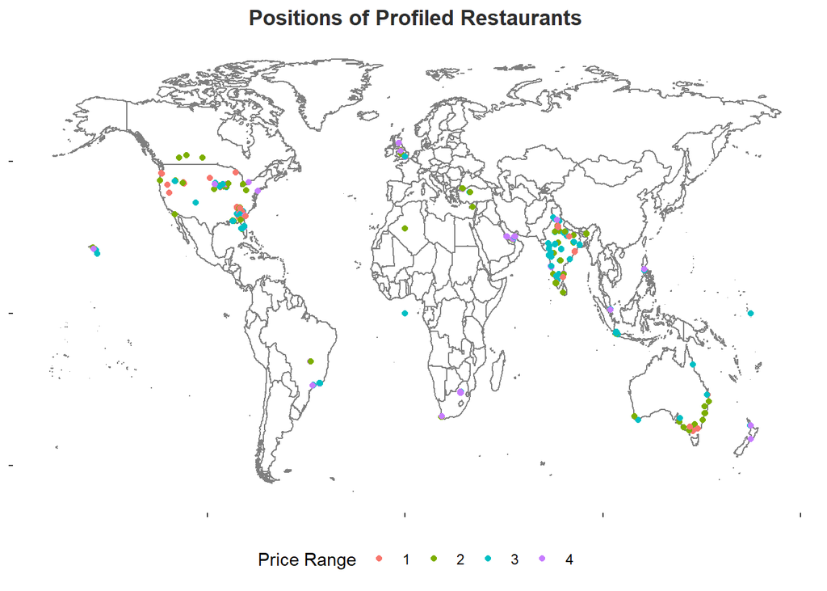

```r
WorldMap <- map_data('world')

# 只取Antarctica以外的區域
WorldMap %>% filter(region != "Antarctica") -> WorldMap
WorldMap <- fortify(WorldMap)

# 取出zomato資料的經緯度及價格區間
zomato_world <- df %>% select(Latitude,Longitude,Price.range) %>% mutate(Price.range=as.factor(Price.range))

# 畫出背景地圖
p <- ggplot() +
  geom_map(data=WorldMap, map=WorldMap, aes(x=long, y=lat, group=group, map_id=region),
           fill="white", colour="#7f7f7f", size=0.5)
# 加上資料點
p <- p + geom_point(data=zomato_world,aes(x=Longitude,y=Latitude,color=Price.range))

p <- p +
  theme(panel.background = element_blank(),
        axis.title = element_blank(),
        axis.text = element_blank(),
        legend.position = 'bottom',
        legend.background = element_blank(),
        plot.title = element_text(hjust=0.5,face='bold',color='#2d2d2d'),
        legend.key = element_rect(fill='white',color = 'transparent')) +
  labs(title='Positions of Profiled Restaurants', color='Price Range')

p
```

**=> 觀察圖片可以發現，大多數的餐廳位於印度和美國**

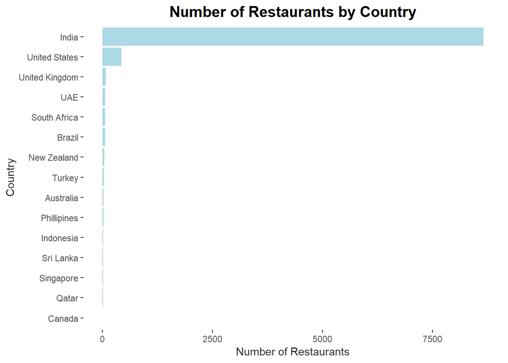

```r
df %>%
  select(Restaurant.ID,Country) %>%
  unique() %>%
  group_by(Country) %>%
  summarise(n=n()) %>%
  ggplot(aes(x=reorder(Country,n),y=n)) +
  geom_bar(stat='identity',fill='lightblue') + coord_flip() +
  theme(panel.background = element_blank(),
        strip.background = element_blank(),
        axis.title = element_text(color = '#2d2d2d'),
        strip.text.x = element_text(color='#2d2d2d',face='bold',size=10),
        plot.title = element_text(hjust=0.5,face='bold',size=15)) +
  labs(x='Country',y='Number of Restaurants',title="Number of Restaurants by Country")
```

**=> 由柱狀圖更可清楚觀察各國家餐廳數量上的差距**

### **4. 針對印度的餐廳進行探索**

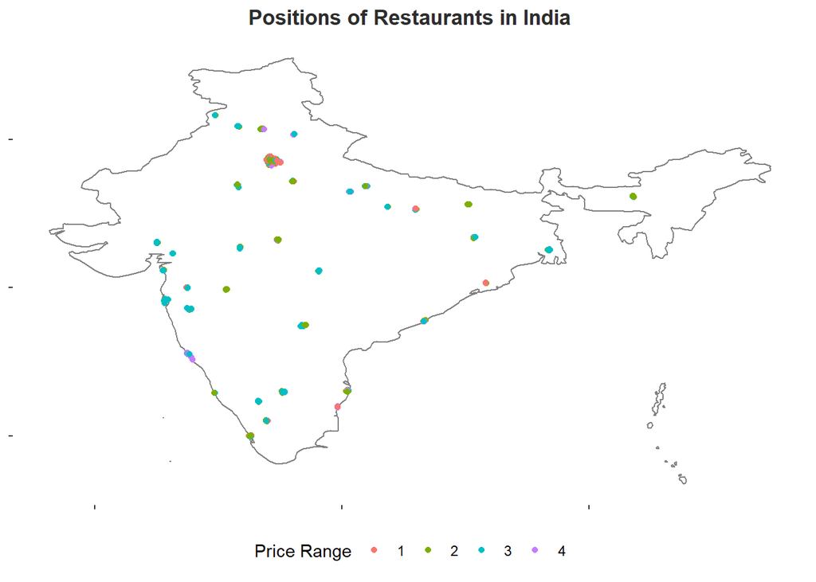

#### **4.1 How many restaurants have been profiled in India?**

```r
df %>% filter(Country=='India') %>%
  select(Restaurant.ID) %>%
  unique() %>%
  nrow()
```

```
## [1] 8652
```

**=>此資料集中一共有8652筆位於印度的餐廳資料**

#### **4.2 In which cities are these restaurants present in ?**

- `summarise()`: 計算統計值
- 因為 ggplot2 的 `geom_bar()` 預設會協助我們計算類別變數中的相異個數：`stat = "count"`，也就是 table() 函數做的事情，假如長條的高度已經在資料框中被計算好，那麼就用 `stat = "identity"` 就可以了
- `coord_flip()`: x,y 翻轉

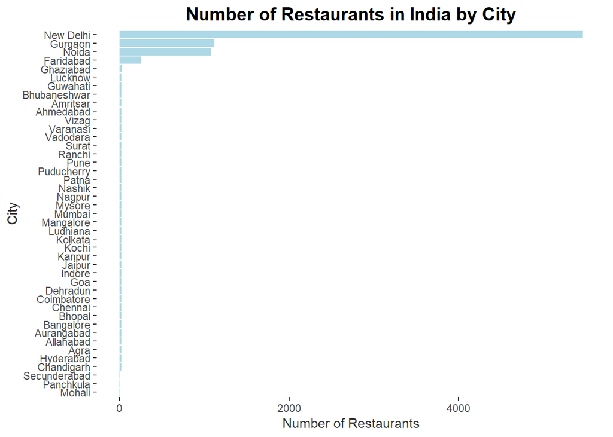

```r
df %>%
  filter(Country=='India') %>%
  select(Restaurant.ID,City) %>%
  unique() %>%
  group_by(City) %>%
  summarise(n=n()) %>%
  ggplot(aes(x=reorder(City,n),y=n)) + geom_bar(stat='identity',fill='lightblue') +
  coord_flip() +
  labs(x='City',y='Number of Restaurants',title="Number of Restaurants in India by City") +
  theme(panel.background = element_blank(),
        strip.background = element_blank(),
        axis.title = element_text(color = '#2d2d2d'),
        strip.text.x = element_text(color='#2d2d2d',face='bold',size=10),
        plot.title = element_text(hjust=0.5,face='bold',size=15))
```

**=> 多數餐廳都位於首都New Delhi，Guragon, Noida, Faridabad 此三城市都分布在印度北部，距首都不遠處**

#### **4.3 How do the prices vary for each type of price range?**

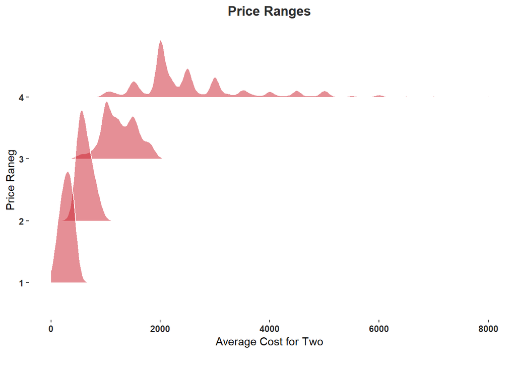

```r
df %>%
  filter(Country=="India") %>%
  ggplot(aes(y = as.factor(Price.range))) +
  geom_density_ridges(aes(x = Average.Cost.for.two),
                      alpha = .5, color = "white", from = 0, to = 8000,fill='#cb202d') +
  labs(x = "Average Cost for Two",
       y = "Price Raneg",
       title = "Price Ranges",
       subtitle = "",
       caption = "") +
  theme(plot.title = element_text(hjust=0.5,face='bold',color='#2d2d2d'),
        panel.background = element_blank(),
        strip.text = element_text(face='bold',color='#2d2d2d'),
        axis.text.x = element_text(face='bold',color='#2d2d2d'),
        axis.text = element_text(face='bold',color='#2d2d2d'))
```

**=> Price Range = 1 的全距最小，Price Range = 4 的全距最大**

#### **4.4 For each price range what were the top rated places?**

```r
#Sys.setlocale('LC_ALL','C')
Sys.setlocale(category='LC_ALL', locale='English_United States.1252')
```

```
## [1] "LC_COLLATE=English_United States.1252;LC_CTYPE=English_United States.1252;LC_MONETARY=English_United States.1252;LC_NUMERIC=C;LC_TIME=English_United States.1252"
```

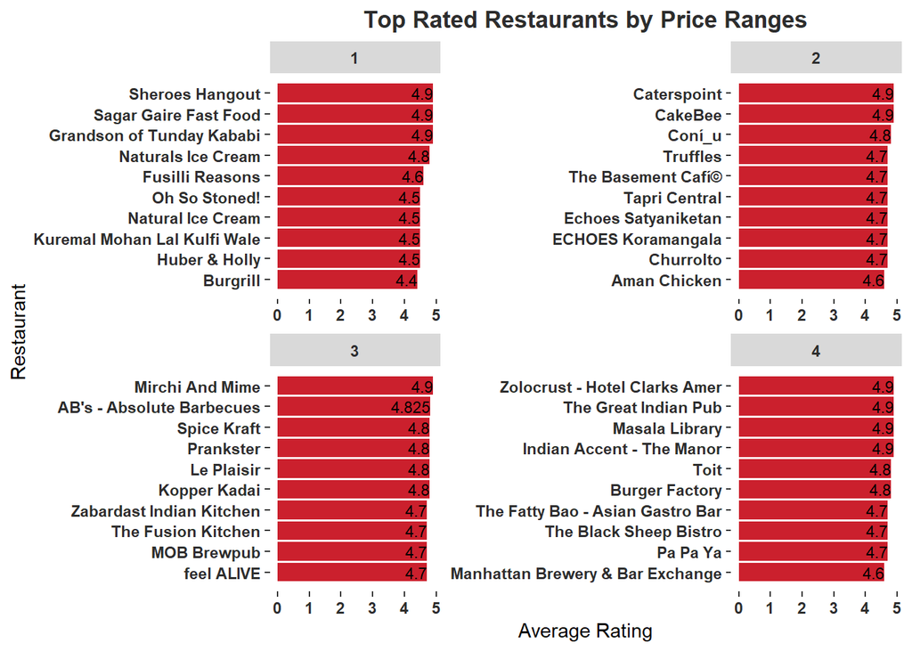

```r
for(i in 1:4){

  assign(paste("test"),zomato %>% filter(Country.Code==1,Price.range==i) %>%
           group_by(Restaurant.Name,Price.range) %>%
           summarise(avg_rating=mean(Aggregate.rating)) %>% ungroup() %>%
           unique() %>%
           arrange(desc(avg_rating)) %>%
           head(10))
  #print(test)
  if(i==1){
    zomato_ranking_for_price_range <- test
  }
  else{
    zomato_ranking_for_price_range <- bind_rows(zomato_ranking_for_price_range,test)
  }
  #print(dim(test))

}

d <- zomato_ranking_for_price_range %>%
  ungroup() %>%
  arrange(Price.range,avg_rating) %>%
  mutate(.r=row_number()) %>%
  mutate(Restaurant.Name=gsub('\"'," ",(Restaurant.Name),fixed=TRUE))
#print(d)

d$Restaurant.Name <- as.character(d$Restaurant.Name)

p <- ggplot(d,aes(.r, avg_rating)) +
  geom_bar(stat='identity', fill='#cb202d') +
  geom_text(stat='identity', aes(label=avg_rating), hjust=1, color=I("black"), size=3) +
  facet_wrap(~Price.range, scales='free')+
  scale_x_continuous(breaks=d$.r, labels=d$Restaurant.Name)+
  coord_flip() +
  theme(plot.title = element_text(hjust=0.5, face='bold', color='#2d2d2d'),
        panel.background = element_blank(),
        strip.text = element_text(face='bold', color='#2d2d2d'),
        axis.text.x = element_text(face='bold', color='#2d2d2d'),
        axis.text = element_text(face='bold', color='#2d2d2d')) +
  labs(y='Average Rating',x='Restaurant', title='Top Rated Restaurants by Price Ranges')

p
```

**=> Price Range = 3, 4 的評分普遍較高**

#### **4.5 How many restaurants have Online Delivery in India?**

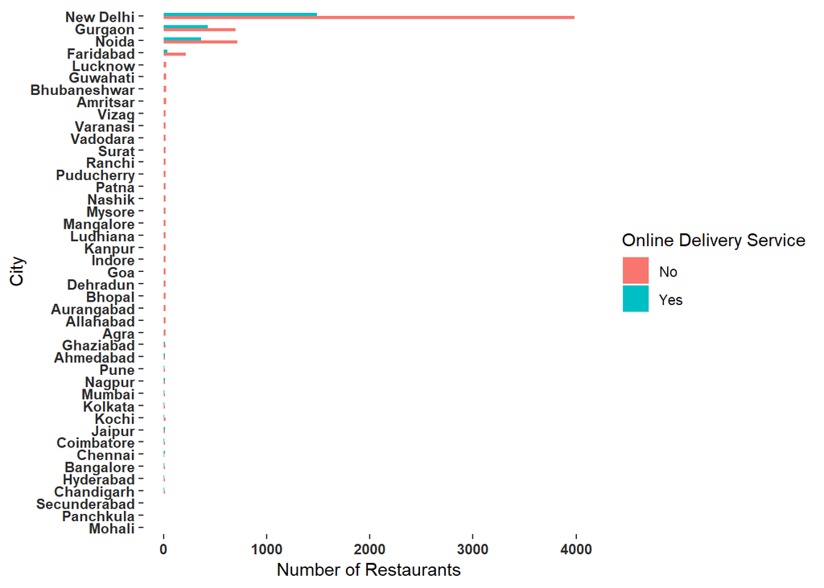

```r
df %>%
  filter(Country=="India") %>%
  select(Restaurant.ID,Has.Online.delivery,City) %>%
  unique() %>%
  group_by(City,Has.Online.delivery) %>%
  summarise(n=n()) %>%
  ungroup() %>%
  rename(`Online Delivery Service`=Has.Online.delivery) %>%
  ggplot(aes(x=reorder(City,n),y=n,fill=`Online Delivery Service`)) +
  geom_bar(stat='identity',position='dodge',width = 0.5) +
  labs(x='City',y='Number of Restaurants') +
  coord_flip() +
  theme(plot.title = element_text(hjust=0.5,face='bold',color='#2d2d2d'),
        panel.background = element_blank(),
        strip.text = element_text(face='bold',color='#2d2d2d'),
        axis.text.x = element_text(face='bold',color='#2d2d2d'),
        axis.text = element_text(face='bold',color='#2d2d2d'))
```

**=> 大多數的餐廳都沒有提供Online Delivery Service, 只有前幾大城市的部分餐廳有提供**

#### **4.6 What are the most popular cuisines in India?**

- `unnest_tokens()`: from `tidytext` package

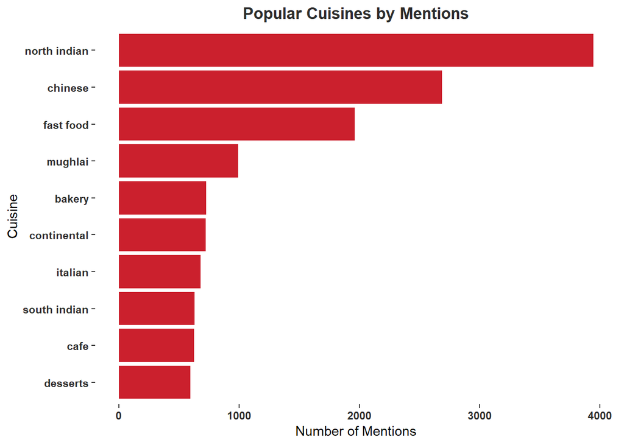

```r
#改善原本只使用2-grams的格式
my_token = function(t) str_split(t,", ")

df %>%
  filter(Country=="India") %>%
  select(Restaurant.ID,Cuisines,Average.Cost.for.two) %>%
  unique() %>%
  mutate(Cuisines=as.character(Cuisines)) %>%
  unnest_tokens(style, Cuisines, token=my_token) %>%
  group_by(style) %>%
  summarise(n=n()) %>%
  arrange(desc(n)) %>%
  top_n(10) %>%
  ggplot(aes(x=reorder(style,n),y=n)) +
  geom_bar(stat='identity',fill='#cb202d') +
  coord_flip() +
  theme(plot.title = element_text(hjust=0.5,face='bold',color='#2d2d2d'),
        panel.background = element_blank(),
        strip.text = element_text(face='bold',color='#2d2d2d'),
        axis.text.x = element_text(face='bold',color='#2d2d2d'),
        axis.text = element_text(face='bold',color='#2d2d2d')) +
  labs(x='Cuisine',y='Number of Mentions',title='Popular Cuisines by Mentions')
```

**=> 多數餐廳分布在北印度，north indian擁有最多筆資料很合理，特別的是Chinese food 也佔有一席之地呢！**

#### **4.7 Is there a relationship between Price range,Votes and Average Cost for two?**

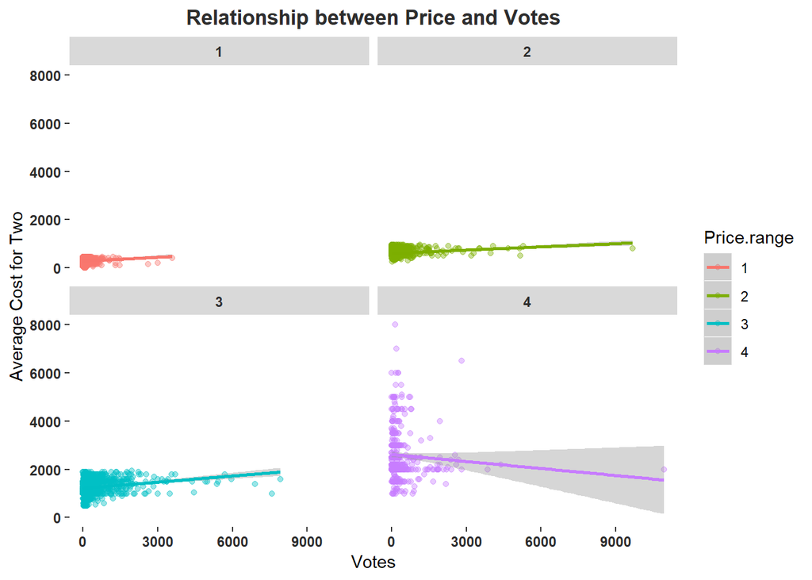

```r
df %>%
  filter(Country=="India") %>%
  mutate(Price.range=as.factor(Price.range)) %>%
  ggplot(aes(x=Votes,y=Average.Cost.for.two,color=Price.range)) +
  geom_point(alpha=0.4) +
  labs(x='Votes',y='Average Cost for Two',
       title='Relationship between Price and Votes') +
  facet_wrap(~Price.range)+
  geom_smooth(method='lm')+
  theme(plot.title = element_text(hjust=0.5,face='bold',color='#2d2d2d'),
        panel.background = element_blank(),
        strip.text = element_text(face='bold',color='#2d2d2d'),
        axis.text.x = element_text(face='bold',color='#2d2d2d'),
        axis.text = element_text(face='bold',color='#2d2d2d'))
```

**=> 很意外地發現只有Price Range = 4 的 votes和cost線斜率為負的，可能是因為此區間的價位較高，能獲得高票數的店也相對有較多的客人(價格較低)，相反地價格越貴的店客人數也可能比較少**

#### **4.8 Average Votes for restaurants that do/ do not have table booking, that do/do not have online delivery option and that do/ do not have switch to order menu**

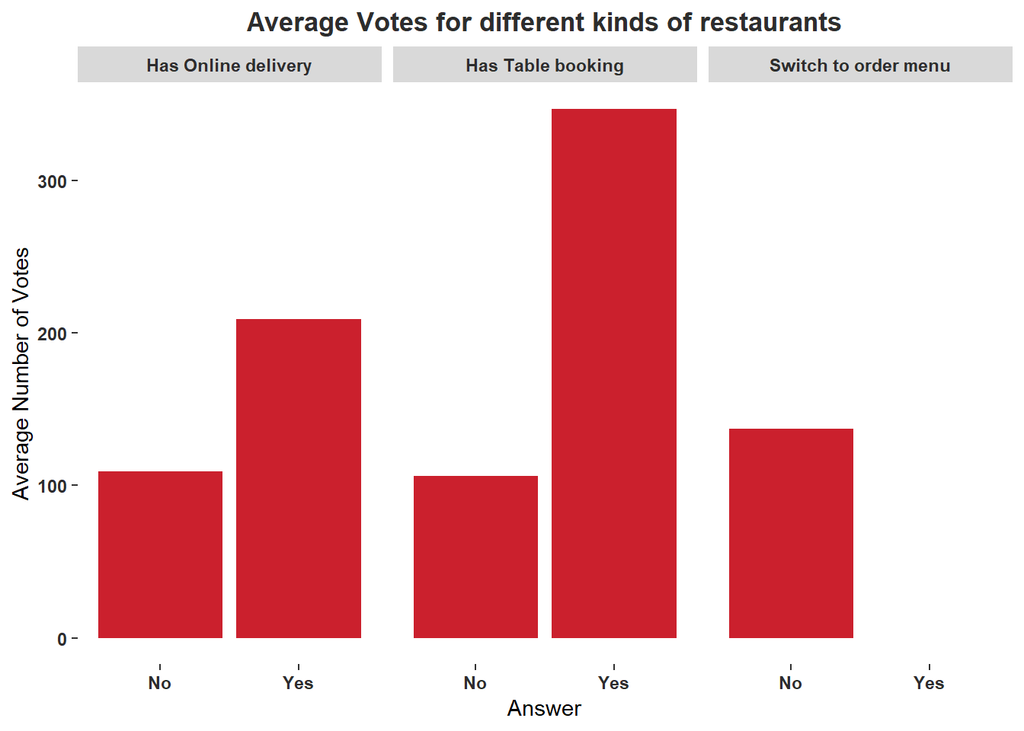

```r
df %>%
  filter(Country=="India") %>%
  select(Votes, Switch.to.order.menu, Has.Table.booking, Has.Online.delivery) %>%
  tidyr::gather(type, value, 2:4) %>%
  mutate(type=gsub("[.]"," ",type)) %>%
  group_by(type, value) %>%
  summarise(mean_votes = mean(Votes,na.rm=TRUE)) %>%
  ggplot(aes(x=value,y=mean_votes)) +
  geom_bar(stat='identity',fill='#cb202d') +
  facet_wrap(~type) +
  labs(x='Answer', y='Average Number of Votes',
       title='Average Votes for different kinds of restaurants') +
  theme(plot.title = element_text(hjust=0.5,face='bold',color='#2d2d2d'),
        panel.background = element_blank(),
        strip.text = element_text(face='bold',color='#2d2d2d'),
        axis.text.x = element_text(face='bold',color='#2d2d2d'),
        axis.text = element_text(face='bold',color='#2d2d2d'))
```

**=> 有Online deliver 和 Table booking的餐廳都有較高的平均票數**

**=> Order menu 在此資料集中沒有意義，因為沒有任何一家餐廳有提供此功能**

### **5. 總結**

- 餐廳主要分布在印度
- 尤其又以印度的首都New Delhi最多
- 大多數印度的餐廳都沒有提供Online Delivery Service
- 印度最受歡迎的三種食物類型為：north indian, chinese, fast food
- Price 和 vote 間沒有明顯的關係
- Switch.to.order.menu 在此資料集中是無效欄位